# Project: Investigate Gapminder Indicators Dataset

- Introduction
- Data Wrangling
- Exploratory Data Analysis
- Conclusions

## Introduction

In this report I will attempt to show relationships and trends among some selected indicators from the excellent site [Gapminder](https://www.gapminder.org/data/). The data selected was chosen for their importance on showing trends and relationships based on annual values of three indicators: *Income per Person, Life Expectancy, and Human Development Index.*

The data was first downloaded, reshaped, merged, and lastly cleaned. Statistical investigations were performed which then led to the main questions of this invistigation which were discuessed and followed up with conclusions.

The main questions posed for this study will be:

> - **(1)** How does the Life Expectancy indecator differ between World Bank Regions?
> - **(2-a)** What are the annual trends of selected variabls for World Bank Region?
> - **(2-b)** What are the annual trends of selected variabls for members of OECD and G77?
> - **(3)** Overall, what is the relationship between our selected indicators?

```python
import numpy as np
import pandas as pd
import matplotlib.pyplot as plt
import seaborn as sns
%matplotlib inline
```

## Data Wrangling

> In this section of the report, I loaded in the data, and then reshaped, cleaned, and mereged the dataset for analysis.

### General Properties

The datasets downloaded for this investigation are:

1. Income per person (GDP/capita, PPP$ inflation-adjusted): Gross domestic product per person adjusted for differences in purchasing power (in international dollars, fixed 2011 prices, PPP based on 2011 ICP).
2. Life expectancy (years): The average number of years a newborn child would live if current mortality patterns were to stay the same.
3. Human Development Index (HDI): HDI is an index used to rank countries by level of "human development". It contains three dimensions: health level, educational level and living standard. I updated this dataset from United Nations Development Programme (UNDP) site - Human Development Data (1990-2018).
4. Gapminder maintain a table catograizing each country in several ways of which I used "members_oecd_g77" and "world_bank_region".

```python
df_income = pd.read_csv('income_per_person_gdppercapita_ppp_inflation_adjusted.csv')
df_income.head()
```

|  | country | 1800 | 1801 | 1802 | 1803 | 1804 | 1805 | 1806 | 1807 | 1808 | ... | 2031 | 2032 | 2033 | 2034 | 2035 | 2036 | 2037 | 2038 | 2039 | 2040 |
| --- | --- | --- | --- | --- | --- | --- | --- | --- | --- | --- | --- | --- | --- | --- | --- | --- | --- | --- | --- | --- | --- |
| 0 | Afghanistan | 603 | 603 | 603 | 603 | 603 | 603 | 603 | 603 | 603 | ... | 2550 | 2600 | 2660 | 2710 | 2770 | 2820 | 2880 | 2940 | 3000 | 3060 |
| 1 | Albania | 667 | 667 | 667 | 667 | 667 | 668 | 668 | 668 | 668 | ... | 19400 | 19800 | 20200 | 20600 | 21000 | 21500 | 21900 | 22300 | 22800 | 23300 |
| 2 | Algeria | 715 | 716 | 717 | 718 | 719 | 720 | 721 | 722 | 723 | ... | 14300 | 14600 | 14900 | 15200 | 15500 | 15800 | 16100 | 16500 | 16800 | 17100 |
| 3 | Andorra | 1200 | 1200 | 1200 | 1200 | 1210 | 1210 | 1210 | 1210 | 1220 | ... | 73600 | 75100 | 76700 | 78300 | 79900 | 81500 | 83100 | 84800 | 86500 | 88300 |
| 4 | Angola | 618 | 620 | 623 | 626 | 628 | 631 | 634 | 637 | 640 | ... | 6110 | 6230 | 6350 | 6480 | 6610 | 6750 | 6880 | 7020 | 7170 | 7310 |

5 rows × 242 columns

```python
df_life_expectancy = pd.read_csv('life_expectancy_years.csv')
df_life_expectancy.head()
```

|  | country | 1800 | 1801 | 1802 | 1803 | 1804 | 1805 | 1806 | 1807 | 1808 | ... | 2091 | 2092 | 2093 | 2094 | 2095 | 2096 | 2097 | 2098 | 2099 | 2100 |
| --- | --- | --- | --- | --- | --- | --- | --- | --- | --- | --- | --- | --- | --- | --- | --- | --- | --- | --- | --- | --- | --- |
| 0 | Afghanistan | 28.2 | 28.2 | 28.2 | 28.2 | 28.2 | 28.2 | 28.1 | 28.1 | 28.1 | ... | 76.5 | 76.6 | 76.7 | 76.9 | 77.0 | 77.1 | 77.3 | 77.4 | 77.5 | 77.7 |
| 1 | Albania | 35.4 | 35.4 | 35.4 | 35.4 | 35.4 | 35.4 | 35.4 | 35.4 | 35.4 | ... | 87.4 | 87.5 | 87.6 | 87.7 | 87.8 | 87.9 | 88.0 | 88.1 | 88.2 | 88.3 |
| 2 | Algeria | 28.8 | 28.8 | 28.8 | 28.8 | 28.8 | 28.8 | 28.8 | 28.8 | 28.8 | ... | 88.3 | 88.4 | 88.5 | 88.6 | 88.7 | 88.8 | 88.9 | 89.0 | 89.1 | 89.2 |
| 3 | Andorra | NaN | NaN | NaN | NaN | NaN | NaN | NaN | NaN | NaN | ... | NaN | NaN | NaN | NaN | NaN | NaN | NaN | NaN | NaN | NaN |
| 4 | Angola | 27.0 | 27.0 | 27.0 | 27.0 | 27.0 | 27.0 | 27.0 | 27.0 | 27.0 | ... | 78.7 | 78.9 | 79.0 | 79.1 | 79.3 | 79.4 | 79.5 | 79.7 | 79.8 | 79.9 |

5 rows × 302 columns

```python
df_hdi = pd.read_csv('hdi_human_development_index.csv')
df_hdi.head()
```

|  | country | 1990 | 1991 | 1992 | 1993 | 1994 | 1995 | 1996 | 1997 | 1998 | ... | 2009 | 2010 | 2011 | 2012 | 2013 | 2014 | 2015 | 2016 | 2017 | 2018 |
| --- | --- | --- | --- | --- | --- | --- | --- | --- | --- | --- | --- | --- | --- | --- | --- | --- | --- | --- | --- | --- | --- |
| 0 | Afghanistan | 0.295 | 0.300 | 0.309 | 0.305 | 0.300 | 0.324 | 0.328 | 0.332 | 0.335 | ... | 0.448 | 0.454 | 0.463 | 0.470 | 0.476 | 0.479 | 0.479 | 0.491 | 0.493 | 0.496 |
| 1 | Albania | 0.635 | 0.618 | 0.603 | 0.608 | 0.616 | 0.628 | 0.637 | 0.636 | 0.646 | ... | 0.725 | 0.738 | 0.752 | 0.759 | 0.761 | 0.762 | 0.764 | 0.788 | 0.789 | 0.791 |
| 2 | Algeria | 0.577 | 0.581 | 0.587 | 0.591 | 0.595 | 0.600 | 0.609 | 0.617 | 0.627 | ... | 0.714 | 0.724 | 0.732 | 0.737 | 0.741 | 0.743 | 0.745 | 0.755 | 0.758 | 0.759 |
| 3 | Andorra | NaN | NaN | NaN | NaN | NaN | NaN | NaN | NaN | NaN | ... | NaN | 0.819 | 0.819 | 0.843 | 0.850 | 0.857 | 0.858 | 0.854 | 0.852 | 0.857 |
| 4 | Angola | NaN | NaN | NaN | NaN | NaN | NaN | NaN | NaN | NaN | ... | 0.488 | 0.495 | 0.508 | 0.523 | 0.527 | 0.531 | 0.533 | 0.570 | 0.576 | 0.574 |

5 rows × 30 columns

#### For the catogries, I will load the "list-of-countries.csv" data and drop all columns that I dont need.

```python
df_countries = pd.read_csv('list-of-countries.csv')
df_countries_mod = df_countries.drop(['four_regions','eight_regions','six_regions',
                                      'World bank, 4 income groups 2017','Latitude','Longitude',
                                      'UN member since'], axis = 1)
df_countries_mod.head()
```

|  | country | members_oecd_g77 | world_bank_region |
| --- | --- | --- | --- |
| 0 | Afghanistan | g77 | South Asia |
| 1 | Albania | others | Europe & Central Asia |
| 2 | Algeria | g77 | Middle East & North Africa |
| 3 | Andorra | others | Europe & Central Asia |
| 4 | Angola | g77 | Sub-Saharan Africa |

#### I will now reshape each of the datasets from wide to long format using the pd.melt method from pandas. Keeping in mind that we limit ourselves to the range of years of available data for HDI because its the shortest time-span (1990-2018).

```python
year = pd.Series(range(1990,2019)).astype(str)
```

```python
def reshaped(df, indicator):
    '''
    helper function to avoid repeating melt method
    input df: dataframe to be turned from wide to long format
          indicator: value to melt
    output reshaped: a melted dataframe
    '''
    reshaped = pd.melt(df, id_vars = ['country'], value_vars = year,
                       var_name='year', value_name = indicator)
    return reshaped
```

```python
df_income_melt = reshaped(df_income, 'income')
df_income_melt.head()
```

|  | country | year | income |
| --- | --- | --- | --- |
| 0 | Afghanistan | 1990 | 1860 |
| 1 | Albania | 1990 | 4460 |
| 2 | Algeria | 1990 | 10300 |
| 3 | Andorra | 1990 | 28400 |
| 4 | Angola | 1990 | 4760 |

```python
df_life_expectancy_melt = reshaped(df_life_expectancy, 'life_expectancy')
df_life_expectancy_melt.head()
```

|  | country | year | life_expectancy |
| --- | --- | --- | --- |
| 0 | Afghanistan | 1990 | 52.6 |
| 1 | Albania | 1990 | 73.3 |
| 2 | Algeria | 1990 | 71.7 |
| 3 | Andorra | 1990 | 79.0 |
| 4 | Angola | 1990 | 47.9 |

```python
df_hdi_melt = reshaped(df_hdi, 'hdi')
df_hdi_melt.head()
```

|  | country | year | hdi |
| --- | --- | --- | --- |
| 0 | Afghanistan | 1990 | 0.295 |
| 1 | Albania | 1990 | 0.635 |
| 2 | Algeria | 1990 | 0.577 |
| 3 | Andorra | 1990 | NaN |
| 4 | Angola | 1990 | NaN |

#### So far so good, I will now merge all the datasets so they will become ready for inspection. Also rearrange the columns.

```python
df_merge = pd.merge(df_income_melt, df_life_expectancy_melt, how='left',
                    left_on=['country','year'], right_on = ['country','year'])
df_merge = pd.merge(df_merge, df_hdi_melt, how='left',
                    left_on=['country','year'], right_on = ['country','year'])
df_merge = pd.merge(df_merge, df_countries_mod, how='left',
                    left_on=['country'], right_on = ['country'])
df_merge = df_merge[['country','members_oecd_g77','world_bank_region','year','income','life_expectancy','hdi']]
```

### Data Cleaning

#### Let's see what we have visually to inspect relationships:

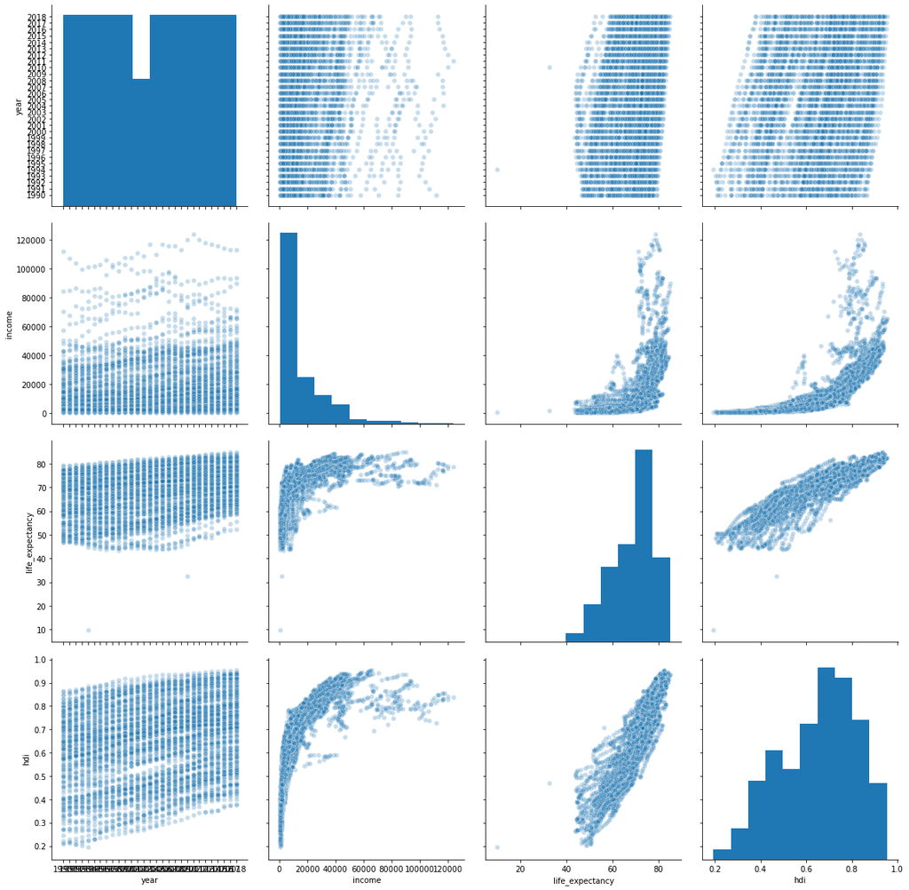

```python
np.warnings.filterwarnings('ignore')
sns.pairplot(df_merge, plot_kws = {'alpha': 0.25}, height = 4);
```

#### Are there any missing values?

```python
df_merge.isnull().sum()
```

```
country                0
members_oecd_g77      58
world_bank_region     29
year                   0
income                 0
life_expectancy      177
hdi                  736
dtype: int64
```

#### Alright, several issues are obvious for cleaning the data:

> 1. **Missing values**: each line in the merged data will be dropped. Reason: it will not contribute anything to the analysis.
> 2. **Outliers**: Two values in life_expectancy seem to be out of expected range from year/life_expectancy above, a good cutoff would be 35 years of age.
> 3. **Income**: data for income seem to be skewed to the left/bottom as seen above. Using transformed data in this instance is common in research, I selected the log value to transform the data for income for later investagations to handle this issue.

```python
df = df_merge.dropna()
df = df[df['life_expectancy'] >= 35]
df['log_income'] = np.log(df['income'])
df.describe(include='all')
```

|  | country | members_oecd_g77 | world_bank_region | year | income | life_expectancy | hdi | log_income |
| --- | --- | --- | --- | --- | --- | --- | --- | --- |
| count | 4806 | 4806 | 4806 | 4806 | 4806.000000 | 4806.000000 | 4806.000000 | 4806.000000 |
| unique | 182 | 3 | 7 | 29 | NaN | NaN | NaN | NaN |
| top | Singapore | g77 | Europe & Central Asia | 2011 | NaN | NaN | NaN | NaN |
| freq | 29 | 3261 | 1293 | 182 | NaN | NaN | NaN | NaN |
| mean | NaN | NaN | NaN | NaN | 15814.516022 | 69.548814 | 0.652569 | 9.010247 |
| std | NaN | NaN | NaN | NaN | 18668.171455 | 8.885150 | 0.166741 | 1.222268 |
| min | NaN | NaN | NaN | NaN | 361.000000 | 43.600000 | 0.203000 | 5.888878 |
| 25% | NaN | NaN | NaN | NaN | 3072.500000 | 63.700000 | 0.523000 | 8.030246 |
| 50% | NaN | NaN | NaN | NaN | 8755.000000 | 71.900000 | 0.677500 | 9.077380 |
| 75% | NaN | NaN | NaN | NaN | 21900.000000 | 76.200000 | 0.783750 | 9.994242 |
| max | NaN | NaN | NaN | NaN | 124000.000000 | 85.000000 | 0.954000 | 11.728037 |

```python
df.isnull().sum()
```

```
country              0
members_oecd_g77     0
world_bank_region    0
year                 0
income               0
life_expectancy      0
hdi                  0
log_income           0
dtype: int64
```

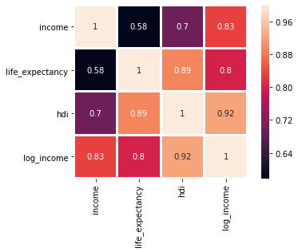

```python
sns.heatmap(df.corr(), annot=True, square=True, linewidths=2);
```

**Looking at the tables above, we find:**

- The dataset have 4,806 lines of data.
- 3 main variables to investigate.
- 29 years and 182 countries.
- 3 catagories for members_oecd_g77 and 7 catagories for world_bank_region.
- Basic descreptive data for: **income, life_expectancy, hdi, and log_income**.
- Correlations between **life_expectancy, hdi**, with **log_income** are much better than those with **income**.
- No missing data.

**The dataset is now ready for Exploratory Data Analysis.**

## Exploratory Data Analysis

### Research Question 1: How does the Life Expectancy indecator differ between World Bank Regions?

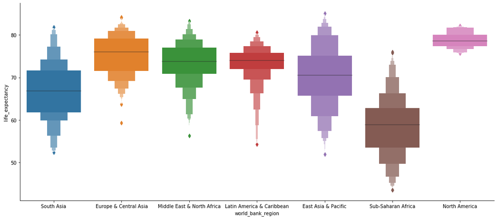

```python
sns.catplot(x='world_bank_region', y='life_expectancy',
            data=df,
            kind='boxen',
            height=6.5, aspect=2.25);
```

We can clearly see that top region for life expectancy is North America for the period from 1990 to 2018. While the Sub-Saharan Africa is the lowest for the same time period.

### Research Question 2a: What are the annual trends of selected variabls for World Bank Region?

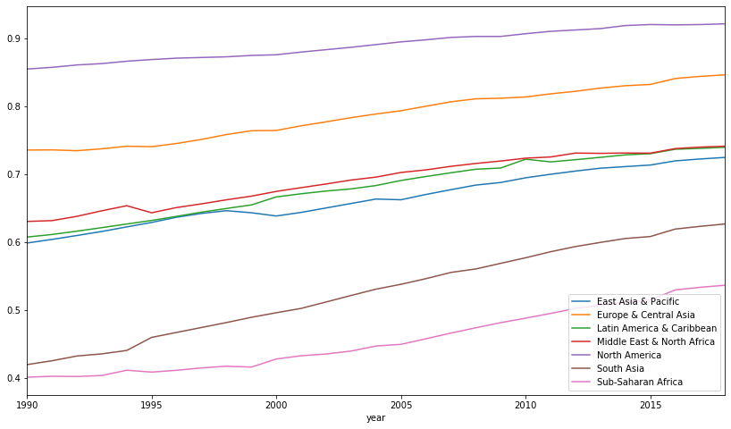

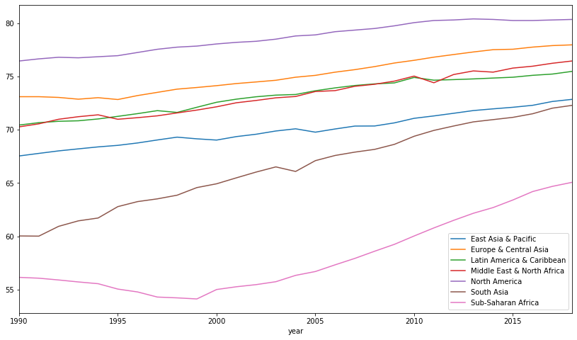

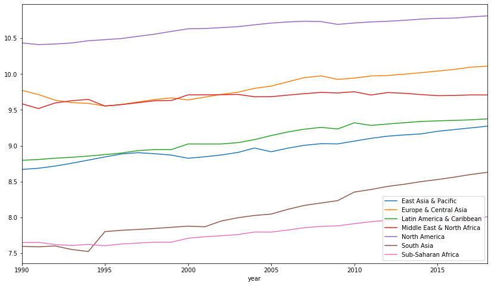

```python
def plot_trend_1(indicator):
    df.groupby(['year','world_bank_region'])[indicator] \
                .mean().unstack().plot(kind='line', \
                figsize=(14,8)).legend(loc='lower right');

plot_trend_1('hdi')
plot_trend_1('life_expectancy')
plot_trend_1('log_income')
```

We notice all our selected indecators are improving over the time period selected (1990 - 2018) as catagorized by World Bank Regions.

### Research Question 2b: What are the annual trends of selected variabls for members of OECD and G77?

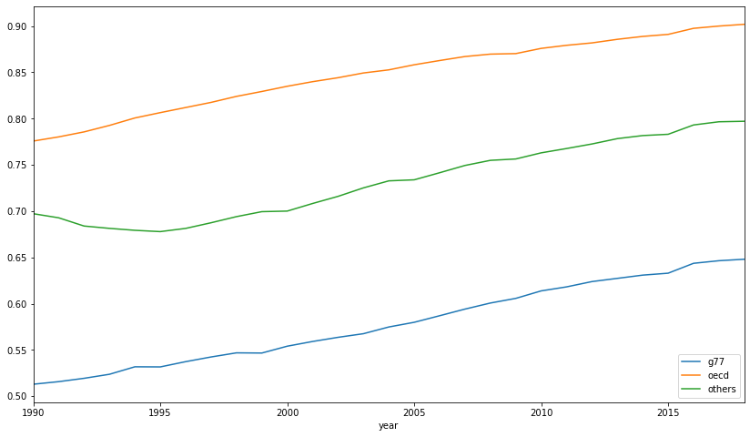

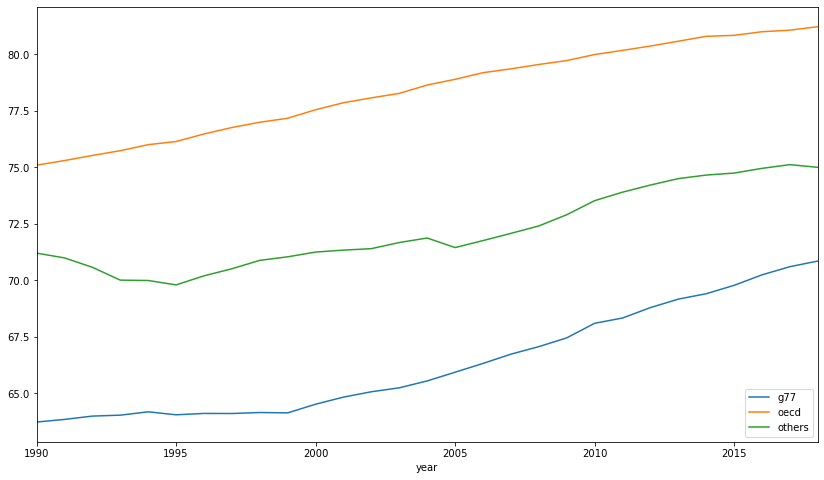

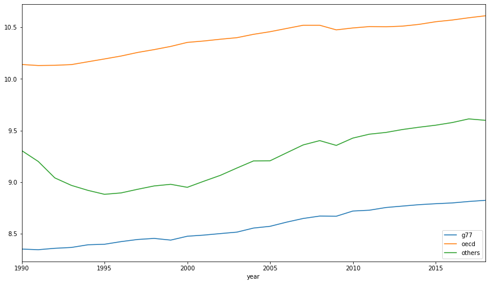

```python
def plot_trend_2(indicator):
    df.groupby(['year','members_oecd_g77'])[indicator] \
                .mean().unstack().plot(kind='line', \
                figsize=(14,8)).legend(loc='lower right');

plot_trend_2('hdi')
plot_trend_2('life_expectancy')
plot_trend_2('log_income')
```

The same can be said about our selected indecators as improving over the time period selected (1990 - 2018) as catagorized by members of OECD and G77.

### Research Question 3: Overall, what is the relationship between our selected indicators?

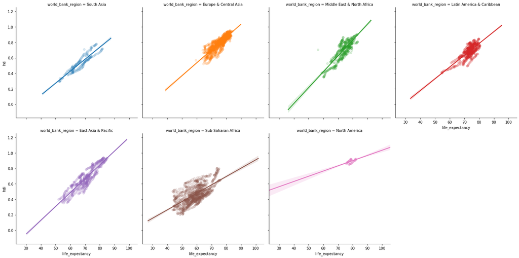

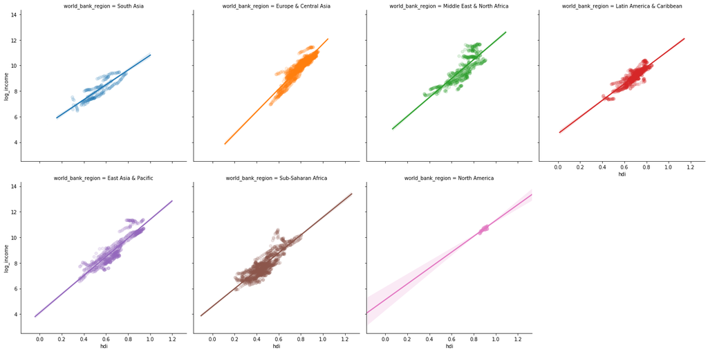

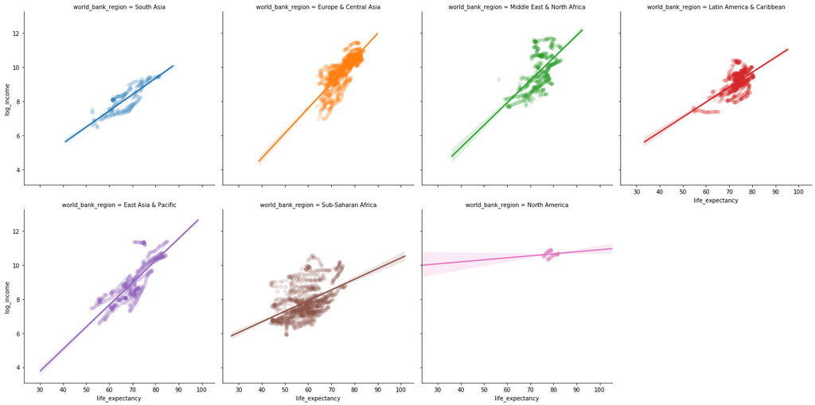

```python
def plot_compare(x, y):
    sns.lmplot(x, y, hue='world_bank_region',
               col='world_bank_region', col_wrap=4,
               scatter_kws={'alpha': 0.15}, data=df);

plot_compare('life_expectancy', 'hdi')
plot_compare('hdi', 'log_income')
plot_compare('life_expectancy', 'log_income')
```

Overall, the three indecators I selected have positive proportional relationships.

## Conclusions

> **Summary:** There are several conclusions from the analysis performed above:
> 1. Life expectancy in North America for the period from 1990 to 2018 was the highest among World Bank Regions. While the Sub-Saharan Africa was the lowest for the same time period.
> 2. All the selected indecators are improving over the time period selected (1990 - 2018) as catagorized by World Bank Regions.
> 3. The same can be said about the selected indecators improving over the time period selected (1990 - 2018) as catagorized by whether they are members of OECD, other or G77.
> 4. Overall, all three indecators selected have positive proportional relationships among them, especially as catagorized by World Bank Regions.

> **Limitations:** The main limitation of this investigation in my opinion is that although life expectancy and income data were available for much longer than HDI data, I had to limit myself to the availble range of HDI data (1990-2015), however, I updated the Gapminder dataset from the original source for three extra years (2016-2018) to have more data points.